# AML-3104 Assignment 1

### [30 Marks, 20%]

### Team Name: PyCoders

Team Members:

1. Bhanu Prakash Mahadevuni – C0850515
2. Deeksha Naikap – C0835440
3. Pramod Reddy Gurrala – C0850493
4. Sai Varun Kollipara – C0828403

## Import libraries

```python
import numpy as np
import matplotlib.pyplot as plt
# You may need some sklearn specific imports, or other standard toolboxes
```

## Load dataset

```python
trainingset = np.loadtxt('training.csv', delimiter=',')
testingset = np.loadtxt('test.csv', delimiter=',')

trainingset
```

```
array([[ 70.,  80.,  82., ...,   0.,   0.,   0.],
       [151., 150., 147., ...,   0.,   0.,   0.],
       [231., 212., 156., ...,   0.,   0.,   0.],
       ...,
       [ 74.,  81.,  87., ...,   1.,   0.,   0.],
       [222., 227., 203., ...,   0.,   0.,   0.],
       [195., 199., 205., ...,   1.,   0.,   0.]])
```

## Split data

```python
n_inputs = 2304 # images are 48 x 48
n_classes = 7 # 7 classes - as defined below
img_dim = 48 # each input image dimension, width and height are both 48

x_training = trainingset[:, 0:n_inputs] # Extract the first 2304 elements - the image
y_training = trainingset[:, n_inputs:n_inputs + n_classes] # Extract the last 7 elements - a one hot category encoding

x_testing = testingset[:, 0:n_inputs] # Extract the first 2304 elements - the image
y_testing = testingset[:, n_inputs:n_inputs + n_classes] # Extract the last 7 elements - a one hot category encoding

x_training = x_training.reshape(x_training.shape[0], 48, 48) # Make samples image shaped
x_testing = x_testing.reshape(x_testing.shape[0], 48, 48) # Make samples image shaped
```

```python
def get_emotion(whichemotion):
    if whichemotion.shape[0] == 1:
        indx = whichemotion[0]
    else:
        indx = np.argmax(whichemotion)
    if indx == 0:
        return 'angry'
    elif indx == 1:
        return 'disgust'
    elif indx == 2:
        return 'fear'
    elif indx == 3:
        return 'happy'
    elif indx == 4:
        return 'sad'
    elif indx == 5:
        return 'surprise'
    elif indx == 6:
        return 'neutral'
```

```
(28709, 48, 48)
(28709, 7)
(3589, 48, 48)
(3589, 7)
```

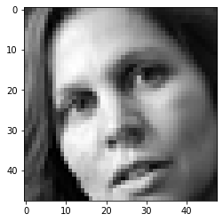

```
facial emotion: neutral
```

```python
print(x_training.shape)
print(y_training.shape)

print(x_testing.shape)
print(y_testing.shape)

sampleindex = np.random.randint(0,1000)
sample = x_training[sampleindex, :]
sample = sample.reshape(48, 48)

plt.imshow(sample, cmap='gray')
plt.show()
print('facial emotion: %s' % get_emotion(y_training[sampleindex, :]))
```

# Part I : Happy or Sad

## For this part you will consider a binary classification problem - categorizing faces as happy or sad

[1 Mark] a. Sample from the data loaded above to include only the happy or sad cases

```python
## Scaling the data
x_training = x_training/255
x_testing = x_testing/255
```

```python
x_training
```

```
array([[[0.2745098 , 0.31372549, 0.32156863, ..., 0.20392157,
         0.16862745, 0.16078431],
        [0.25490196, 0.23921569, 0.22745098, ..., 0.21960784,
         0.20392157, 0.17254902],
        [0.19607843, 0.16862745, 0.21176471, ..., 0.19215686,
         0.21960784, 0.18431373],
        ...,
        [0.35686275, 0.25490196, 0.16470588, ..., 0.28235294,
         0.21960784, 0.16862745],
        [0.30196078, 0.32156863, 0.30980392, ..., 0.41176471,
         0.2745098 , 0.18039216],
        [0.30196078, 0.28235294, 0.32941176, ..., 0.41568627,
         0.42745098, 0.32156863]],

       [[0.59215686, 0.58823529, 0.57647059, ..., 0.50588235,
         0.54901961, 0.47058824],
        [0.59215686, 0.58431373, 0.58431373, ..., 0.47843137,
         0.55294118, 0.5372549 ],
        [0.59215686, 0.59215686, 0.61176471, ..., 0.42745098,
         0.48235294, 0.57254902],
        ...,
        [0.7372549 , 0.7372549 , 0.4745098 , ..., 0.7254902 ,
         0.7254902 , 0.72941176],
        [0.7372549 , 0.73333333, 0.76862745, ..., 0.72941176,
         0.71372549, 0.73333333],
        [0.72941176, 0.72156863, 0.7254902 , ..., 0.75686275,
         0.71764706, 0.72156863]],

       [[0.90588235, 0.83137255, 0.61176471, ..., 0.17254902,
         0.10588235, 0.0627451 ],
        [0.89803922, 0.68627451, 0.58039216, ..., 0.10588235,
         0.1372549 , 0.10588235],
        [0.83921569, 0.61176471, 0.61568627, ..., 0.10980392,
         0.08627451, 0.10980392],
        ...,
        [0.94509804, 0.96078431, 0.98039216, ..., 0.22352941,
         0.39607843, 0.57254902],
        [0.96470588, 0.98039216, 0.98823529, ..., 0.30588235,
         0.41176471, 0.63529412],
        [0.98039216, 0.98431373, 0.98039216, ..., 0.34509804,
```

[output cut: 30 more lines]

```
         0.53333333, 0.5254902 ]],

       [[0.76470588, 0.78039216, 0.80392157, ..., 0.71372549,
         0.54901961, 0.30196078],
        [0.75686275, 0.76862745, 0.79215686, ..., 0.77254902,
         0.64705882, 0.41176471],
        [0.77647059, 0.78431373, 0.8       , ..., 0.81568627,
         0.76862745, 0.61568627],
        ...,
        [0.22352941, 0.28627451, 0.32941176, ..., 0.01176471,
         0.07843137, 0.12941176],
        [0.23921569, 0.28627451, 0.37647059, ..., 0.02352941,
         0.0745098 , 0.16078431],
        [0.23921569, 0.30980392, 0.37254902, ..., 0.02352941,
         0.05882353, 0.14901961]]])
```

```python
# Convert one-hot encoded labels into real-label names
y_training = np.apply_along_axis(get_emotion,1,y_training)
y_testing = np.apply_along_axis(get_emotion,1,y_testing)
```

```python
y_training
```

```
array(['angry', 'angry', 'fear', ..., 'sad', 'angry', 'sad'], dtype='<U5')
```

```python
# Sampling training data to include only happy or sad
hs_train_index = np.any([y_training == 'happy',y_training == 'sad'],axis=0).nonzero()[0]
hs_train_y = y_training[hs_train_index]
hs_train_X = x_training[hs_train_index]

# Sampling training data to include only happy or sad
hs_test_index = np.any([y_testing == 'happy',y_testing == 'sad'],axis=0).nonzero()[0]
hs_test_y = y_testing[hs_test_index]
hs_test_X = x_testing[hs_test_index]

# Converting labels into numerical values (to evaluate and visualize- some metrics works only with numericals)
hs_train_y = (hs_train_y == 'happy').astype(int)
hs_test_y = (hs_test_y == 'happy').astype(int)
```

```python
print(f'Training data {hs_train_X.shape} and {hs_train_y.shape}')
print(f'Testing data {hs_test_X.shape} and {hs_test_y.shape}')
```

```
Training data (12045, 48, 48) and (12045,)
Testing data (1548, 48, 48) and (1548,)
```

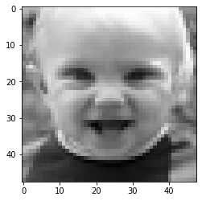

```
facial emotion: Happy
```

```python
# Print a sample image from the sampled dataset
sampleindex = np.random.randint(0,hs_train_X.shape[0])
sample = hs_train_X[sampleindex, :]

emotion = 'Happy' if hs_train_y[sampleindex] == 1 else 'Sad'
plt.imshow(sample, cmap='gray')
plt.show()
print('facial emotion: %s' % emotion)
```

[4 Marks] b. Apply PCA and LDA to represent the faces, display a sample of a few faces for each case. You may consider using one or both of these in the steps that follow if they are of any value (this is for you to decide).

### PCA

```python
# Convert the array to 2-d
happy_sad_2d = hs_train_X.reshape(hs_train_X.shape[0], -1)
```

```python
from sklearn.decomposition import PCA

# Account for 99% of variance
pca_bin = PCA(0.99)
# Transformed image
pca_image_transformed = pca_bin.fit_transform(happy_sad_2d)
```

```python
print(f'The number of original features has been reduced from {happy_sad_2d.shape[1]} to {pca_image_transformed.shape[1]}')
```

```
The number of original features has been reduced from 2304 to 835
```

```python
# Inverese the PCA transformed to original for display
inversed_2d = pca_bin.inverse_transform(pca_image_transformed)
inveresed_3d = inversed_2d.reshape(inversed_2d.shape[0], 48, 48)
```

```python
import random
```

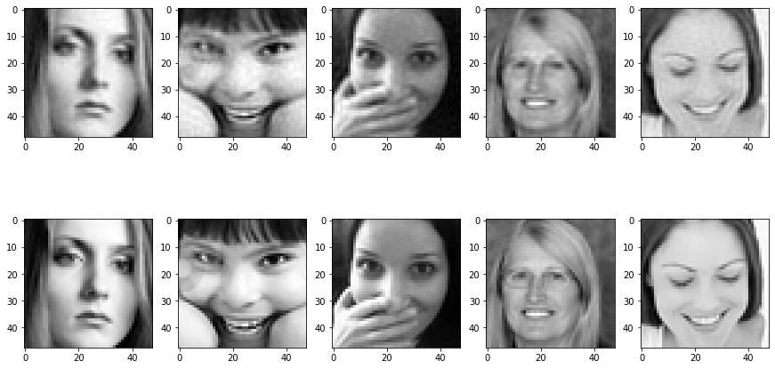

```python
# Compare and display 5 inversed PCA images and its original images
randomlist = random.sample(range(0,inveresed_3d.shape[0]), 5)

plt.figure(figsize=(15,8))
for i in range(5):
    plt.subplot(2,5,i+1)
    plt.imshow(inveresed_3d[randomlist[i], :], cmap='gray')
    plt.subplot(2,5,i+6)
    plt.imshow(hs_train_X[randomlist[i], :], cmap='gray')
plt.show()
```

### LDA

```python
from sklearn.discriminant_analysis import LinearDiscriminantAnalysis

# Perform LDA on the sampled dataset
lda = LinearDiscriminantAnalysis()
lda.fit(happy_sad_2d, hs_train_y)
bin_lda_transformed = lda.transform(happy_sad_2d)
```

```python
print(f'The number of original features has been reduced from {happy_sad_2d.shape[1]} to {bin_lda_transformed.shape[1]}')
```

```
The number of original features has been reduced from 2304 to 1
```

```python
from sklearn.utils.validation import check_is_fitted
from sklearn.utils import check_array, check_X_y

# Perform inverse transform on LDA
def inverse_transform(lda, x):
    if lda.solver == 'lsqr':
        raise NotImplementedError("(inverse) transform not implemented for 'lsqr' "
                                  "solver (use 'svd' or 'eigen').")
    check_is_fitted(lda, ['xbar_', 'scalings_'], all_or_any=any)

    # Numpy's pinverse
    inv = np.linalg.pinv(lda.scalings_)

    x = check_array(x)
    # Perform operation based on the type of solver
    if lda.solver == 'svd':
        x_back = np.dot(x, inv) + lda.xbar_
    elif lda.solver == 'eigen':
        x_back = np.dot(x, inv)

    return x_back
```

```python
# Perform inverse transform
inversed_lda = inverse_transform(lda,bin_lda_transformed)
inversed_lda
```

```
array([[0.44904046, 0.43968253, 0.43188559, ..., 0.42342814, 0.4266329 ,
        0.42904464],
       [0.44841507, 0.4403948 , 0.43052565, ..., 0.42368275, 0.42647637,
        0.42855817],
       [0.44833711, 0.4404836 , 0.43035611, ..., 0.42371449, 0.42645686,
        0.42849753],
       ...,
       [0.4477055 , 0.44120294, 0.42898266, ..., 0.42397163, 0.42629878,
        0.42800623],
       [0.44829212, 0.44053483, 0.4302583 , ..., 0.42373281, 0.4264456 ,
        0.42846254],
       [0.44838588, 0.44042805, 0.43046216, ..., 0.42369464, 0.42646907,
        0.42853546]])
```

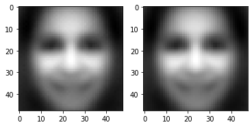

```python
# Visulaize two different images
lda_iveresed_3d = inversed_lda.reshape(inversed_lda.shape[0], 48, 48)
plt.subplot(1,2,1)
plt.imshow(lda_iveresed_3d[0], cmap='gray')
plt.subplot(1,2,2)
plt.imshow(lda_iveresed_3d[1000], cmap='gray')
plt.show()
```

[figure not shown]

```python
#Visulaize the LDA value
randomlist = random.sample(range(0,lda_iveresed_3d.shape[0]), 5)

plt.figure(figsize=(15,8))
for i in range(5):
    plt.subplot(2,5,i+1)
    plt.imshow(bin_lda_transformed[randomlist[i]].reshape(1,-1), cmap='gray')
    plt.subplot(2,5,i+6)
    plt.imshow(hs_train_X[randomlist[i], :], cmap='gray')
plt.show()
```

[2 Marks] c. Apply naive Bayes to classify faces as happy or sad. Report your accuracy.

### Naive Bayes

```python
# Transform the test set
test_pca_x = pca_bin.transform(hs_test_X.reshape(hs_test_X.shape[0],-1))
test_lda_x = lda.transform(hs_test_X.reshape(hs_test_X.shape[0],-1))
```

```python
from sklearn.metrics import confusion_matrix
import seaborn as sns
import pandas as pd
from sklearn import metrics

# Visualize the model evaluation
def model_evaluation(pca_model, lda_model,test_pca_x,test_lda_x,hs_test_y):
    # Predict on test set
    pca_prediction = pca_model.predict(test_pca_x)
    lda_prediction = lda_model.predict(test_lda_x)

    # Plot confusion matrix of PCA
    print("*"*50)
    cmatrix_pca = confusion_matrix(hs_test_y,pca_prediction)
    print("Confusion Matrix for PCA based Model")
    print(cmatrix_pca)

    # Plot confusion matrix of LDA
    print("*"*50)
    cmatrix_lda = confusion_matrix(hs_test_y,lda_prediction)
    print("Confusion Matrix for LDA based Model")
    print(cmatrix_lda)

    # Calculate and print the evaluation metrics
    print("*"*50)
    print("PCA Scores")
    print(f'Accuracy of the model trained with PCA is {metrics.accuracy_score(hs_test_y, pca_prediction)*100:.2f}%')
    print(f'Precision of the model trained with PCA is {metrics.precision_score(hs_test_y, pca_prediction):.3f}')
    print(f'Recall of the model trained with PCA is {metrics.recall_score(hs_test_y, pca_prediction):.3f}')
    print("*"*50)
    print("LDA Scores")
    print(f'Accuracy of the model trained with LDA is {metrics.accuracy_score(hs_test_y, lda_prediction)*100:.2f}%')
    print(f'Precision of the model trained with LDA is {metrics.precision_score(hs_test_y, lda_prediction):.3f}')
    print(f'Recall of the model trained with LDA is {metrics.recall_score(hs_test_y, lda_prediction):.3f}')
    print("*"*50)
```

```python
from sklearn.naive_bayes import GaussianNB

## Training the model
# Training with PCA data
nb_pca = GaussianNB()
nb_pca.fit(pca_image_transformed,hs_train_y)

# Training with LDA data
nb_lda = GaussianNB()
nb_lda.fit(bin_lda_transformed,hs_train_y)
```

```
GaussianNB()
```

```python
# Visualize the evaluation
model_evaluation(nb_pca, nb_lda,test_pca_x,test_lda_x,hs_test_y)
```

```
Confusion Matrix for PCA based Model
[[273 380]
 [303 592]]
Confusion Matrix for LDA based Model
[[380 273]
 [230 665]]
PCA Scores
Accuracy of the model trained with PCA is 55.88%
Precision of the model trained with PCA is 0.609
Recall of the model trained with PCA is 0.661
LDA Scores
Accuracy of the model trained with LDA is 67.51%
Precision of the model trained with LDA is 0.709
Recall of the model trained with LDA is 0.743
```

[2 Marks] d. Apply Logistic regression to classify faces as happy or sad. Report the accuracy.

### Logistic Regression

```python
from sklearn.linear_model import LogisticRegression

## Training the model
# Training with PCA data
lr_pca = LogisticRegression(solver = 'lbfgs', max_iter=1000)
lr_pca.fit(pca_image_transformed,hs_train_y)

# Training with LDA data
lr_lda = LogisticRegression(solver = 'lbfgs', max_iter=1000)
lr_lda.fit(bin_lda_transformed,hs_train_y)
```

```
LogisticRegression(max_iter=1000)
```

```python
# Visualize the evaluation
model_evaluation(lr_pca, lr_lda,test_pca_x,test_lda_x,hs_test_y)
```

```
Confusion Matrix for PCA based Model
[[376 277]
 [177 718]]
Confusion Matrix for LDA based Model
[[380 273]
 [233 662]]
PCA Scores
Accuracy of the model trained with PCA is 70.67%
Precision of the model trained with PCA is 0.722
Recall of the model trained with PCA is 0.802
LDA Scores
Accuracy of the model trained with LDA is 67.31%
Precision of the model trained with LDA is 0.708
Recall of the model trained with LDA is 0.740
```

[2 Marks] e. Apply a Support Vector Machine to classify the faces as happy or sad. Choose parameters / arguments to try to maximize your accuracy. Report the accuracy.

### SVM

```python
from sklearn.model_selection import RandomizedSearchCV
from sklearn.svm import SVC

# Parameters to be considered
param_grid = {'C': [0.1,1], 'gamma': [1,0.1,0.01],'kernel': ['poly', 'sigmoid']}

# Find a model with better accuracy
pca_svc = SVC(probability=True)
pca_random_search = RandomizedSearchCV(pca_svc,
                        param_distributions=param_grid,
                        scoring='accuracy',
                        cv=2,
                        verbose=20,
                        n_jobs=-1)
```

```python
pca_random_search.fit(pca_image_transformed,hs_train_y)
pca_svc = pca_random_search.best_estimator_
```

```
Fitting 2 folds for each of 10 candidates, totalling 20 fits
```

```python
lda_svc = SVC(probability=True)
lda_random_search = RandomizedSearchCV(lda_svc,
                        param_distributions=param_grid,
                        scoring='accuracy',
                        cv=3,
                        verbose=20,
                        n_jobs=-1)
```

```python
lda_random_search.fit(bin_lda_transformed,hs_train_y)
lda_svc = lda_random_search.best_estimator_
```

```
Fitting 3 folds for each of 10 candidates, totalling 30 fits
```

```python
print('='*50)
print('Model trained with PCA data')
print("best estimator: " + str(pca_random_search.best_estimator_))
print("best params: " + str(pca_random_search.best_params_))
print('best score:', pca_random_search.best_score_)
print('='*50)
print('='*50)
print('Model trained with LDA data')
print("best estimator: " + str(lda_random_search.best_estimator_))
print("best params: " + str(lda_random_search.best_params_))
print('best score:', lda_random_search.best_score_)
print('='*50)
```

```
==================================================
Model trained with PCA data
best estimator: SVC(C=0.1, gamma=0.1, kernel='poly', probability=True)
best params: {'kernel': 'poly', 'gamma': 0.1, 'C': 0.1}
best score: 0.6908263286980336
==================================================
==================================================
Model trained with LDA data
best estimator: SVC(C=0.1, gamma=0.1, kernel='sigmoid', probability=True)
best params: {'kernel': 'sigmoid', 'gamma': 0.1, 'C': 0.1}
best score: 0.7920298879202989
==================================================
```

```python
# Visualize the evaluation
model_evaluation(pca_svc,lda_svc,test_pca_x,test_lda_x,hs_test_y)
```

```
Confusion Matrix for PCA based Model
[[388 265]
 [172 723]]
Confusion Matrix for LDA based Model
[[374 279]
 [229 666]]
PCA Scores
Accuracy of the model trained with PCA is 71.77%
Precision of the model trained with PCA is 0.732
Recall of the model trained with PCA is 0.808
LDA Scores
Accuracy of the model trained with LDA is 67.18%
Precision of the model trained with LDA is 0.705
Recall of the model trained with LDA is 0.744
```

[1 Mark] f. Which of the approaches above allow you to reliably determine the degree of happiness or sadness (i.e. how happy or how sad)? Which do you trust the most?

### Model Comparision

[2 Marks] g. Based on your answer to f. show the 5 happiest faces and the 5 saddest faces.

```
Sad faces
```

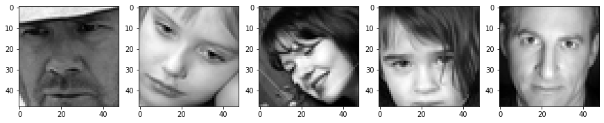

```
Happy faces
```

[figure not shown]

```python
# Display 5 happy and sad faces from test set
prediction = lr_pca.predict(test_pca_x)
sad_index = np.argwhere(prediction == 0)
happy_index = np.argwhere(prediction == 1)

random_sad = random.sample(list(sad_index.reshape(-1)), 5)
random_happy = random.sample(list(happy_index.reshape(-1)), 5)

plt.figure(figsize=(15,8))
print('Sad faces')
for i in range(5):
    plt.subplot(1,5,i+1)
    plt.imshow(hs_test_X[random_sad[i]], cmap='gray')
plt.show()

plt.figure(figsize=(15,8))
print(f'Happy faces')
for i in range(5):
    plt.subplot(1,5,i+1)
    plt.imshow(hs_test_X[random_happy[i]], cmap='gray')
plt.show()
```

# Part II : Multi-class

## For this part you will repeat the tasks in Part I, but instead consider the multi-class problem and classify inputs according to all 7 classes.

[4 Marks] a. Apply PCA and LDA to represent the faces, display a sample of a few faces for each case. Produce a plot for PCA showing the cumulative variance captured by adding additional principal components (e.g. 1st PC, 1st + 2nd PC, etc.). On the same figure, plot the same curve for only happy and sad faces used in part 1.

Similar to Part I, the procedure to apply PDA and LDA will be the same. Additionally, the cumulative variance will be captured and plotted on a graph to compare the binary and multi-class classes.

### Multi-class PCA

```python
# Convert the array to 2-d
x_training_2d = x_training.reshape(x_training.shape[0], -1)

# Account for 99% of variance
pca_multi = PCA(0.99)
# Transformed image
multi_pca_transformed = pca_multi.fit_transform(x_training_2d)

print(f'{x_training_2d.shape[1]} features has been reduced to {multi_pca_transformed.shape[1]}')
```

```
2304 features has been reduced to 880
```

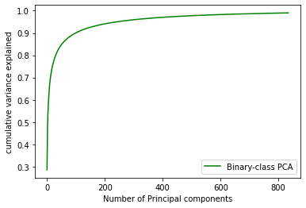

```python
plt.plot(np.cumsum(pca_bin.explained_variance_ratio_),'green', label='Binary-class PCA')
plt.legend();
plt.xlabel('Number of Principal components')
plt.ylabel('cumulative variance explained')
plt.show()
```

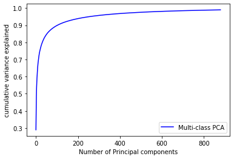

```python
plt.plot(np.cumsum(pca_multi.explained_variance_ratio_), 'blue', label='Multi-class PCA')
plt.legend();
plt.xlabel('Number of Principal components')
plt.ylabel('cumulative variance explained')
plt.show()
```

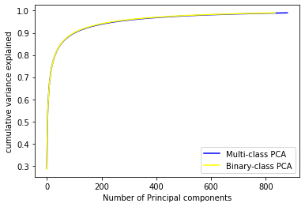

```python
# Comparing variance explained by both PCA
plt.plot(np.cumsum(pca_multi.explained_variance_ratio_), 'blue', label='Multi-class PCA')
plt.plot(np.cumsum(pca_bin.explained_variance_ratio_),'yellow', label='Binary-class PCA')
plt.legend();
plt.xlabel('Number of Principal components')
plt.ylabel('cumulative variance explained')
plt.show()
```

```python
print(np.cumsum(pca_multi.explained_variance_ratio_)[-5:])
print(np.cumsum(pca_bin.explained_variance_ratio_)[-5:])
```

```
[0.98992763 0.98994974 0.9899718  0.98999374 0.99001563]
[0.9899285  0.98995171 0.98997488 0.98999799 0.99002102]
```

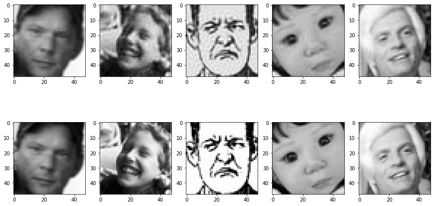

```python
# Inverese the PCA transformed to original for display
inversed_training_2d = pca_multi.inverse_transform(multi_pca_transformed)
inveresed_training_3d = inversed_training_2d.reshape(inversed_training_2d.shape[0], 48, 48)

randomlist = random.sample(range(0,inveresed_training_3d.shape[0]), 5)

plt.figure(figsize=(15,8))
for i in range(5):
    plt.subplot(2,5,i+1)
    plt.imshow(inveresed_training_3d[randomlist[i], :], cmap='gray')
    plt.subplot(2,5,i+6)
    plt.imshow(x_training[randomlist[i], :], cmap='gray')
plt.show()
```

### Multi-class LDA

```python
from sklearn.preprocessing import LabelEncoder
from sklearn.discriminant_analysis import LinearDiscriminantAnalysis

# Label encoding the output variables
label_encoder = LabelEncoder()
y_train_label = label_encoder.fit_transform(y_training)
# Hold the classes as list for visualizing later
label_order = list(label_encoder.classes_)
```

```python
# Performing LDA on multi-label classification
lda_multi = LinearDiscriminantAnalysis()
lda_multi.fit(x_training_2d, y_train_label)
multi_lda_transformed = lda_multi.transform(x_training_2d)

print(f'{x_training_2d.shape[1]} features has been reduced to {multi_lda_transformed.shape[1]}')
```

```
2304 features has been reduced to 6
```

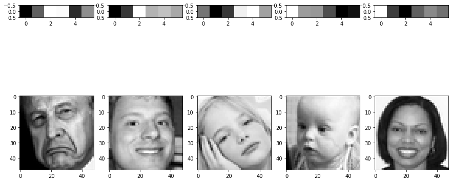

```python
randomlist = random.sample(range(0,lda_iveresed_3d.shape[0]), 5)

plt.figure(figsize=(15,8))
for i in range(5):
    plt.subplot(2,5,i+1)
    plt.imshow(multi_lda_transformed[randomlist[i]].reshape(1,-1), cmap='gray')
    plt.subplot(2,5,i+6)
    plt.imshow(x_training[randomlist[i], :], cmap='gray')
plt.show()
```

```python
# Transform the test set
test_pca_x = pca_multi.transform(x_testing.reshape(x_testing.shape[0],-1))
test_lda_x = lda_multi.transform(x_testing.reshape(x_testing.shape[0],-1))
test_y = label_encoder.transform(y_testing)
```

```python
from sklearn.metrics import confusion_matrix, ConfusionMatrixDisplay
```

```python
# Evaluate multi-label classification model
def model_multi_evaluation2(pca_model, lda_model,test_pca_x,test_lda_x,test_y,label_order):
    pca_prediction = pca_model.predict(test_pca_x)
    lda_prediction = lda_model.predict(test_lda_x)

    plt.figure(figsize=(18,5))
    # Plot the PCA model
    cmatrix_pca = confusion_matrix(test_y,pca_prediction)
    disp_pca = ConfusionMatrixDisplay(confusion_matrix=cmatrix_pca, display_labels=label_order)
    disp_pca.plot()

    # Plot the LDA model
    cmatrix_lda = confusion_matrix(test_y,lda_prediction)
    disp_lda = ConfusionMatrixDisplay(confusion_matrix=cmatrix_lda, display_labels=label_order)
    disp_lda.plot()

    plt.show()

    # Calculate and print the accuracy
    print("PCA Scores")
    print(f'Accuracy of the model trained with PCA is {metrics.accuracy_score(test_y, pca_prediction)*100:.2f}%')

    print("LDA Scores")
    print(f'Accuracy of the model trained with LDA is {metrics.accuracy_score(test_y, lda_prediction)*100:.2f}%')
```

[2 Marks] b. Classify the faces using Naive Bayes and report your accuracy.

### Naive Bayes for Multi-class

```python
## Training the model
# Training with PCA data
nb_pca = GaussianNB()
nb_pca.fit(multi_pca_transformed, y_train_label)

# Training with LDA data
nb_lda = GaussianNB()
nb_lda.fit(multi_lda_transformed, y_train_label)
```

```
GaussianNB()
```

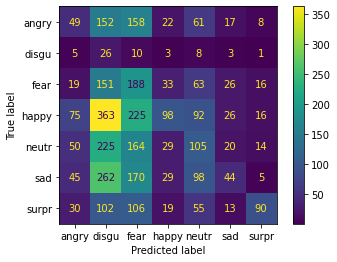

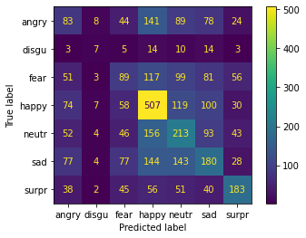

```
PCA Scores
Accuracy of the model trained with PCA is 16.72%
LDA Scores
Accuracy of the model trained with LDA is 35.16%
```

```python
# Visualize the evaluation of test set
model_multi_evaluation2(nb_pca, nb_lda,test_pca_x,test_lda_x,test_y,label_order)
```

[2 Marks] c. Classify the faces using logistic regression and report your accuracy.

### Logistic Regression for Multi-class

```python
## Training the model
# Training with PCA data
lr_pca = LogisticRegression(solver = 'lbfgs', max_iter=1000)
lr_pca.fit(multi_pca_transformed, y_train_label)

# Training with LDA data
lr_lda = LogisticRegression(solver = 'lbfgs', max_iter=1000)
lr_lda.fit(multi_lda_transformed, y_train_label)
```

```
LogisticRegression(max_iter=1000)
```

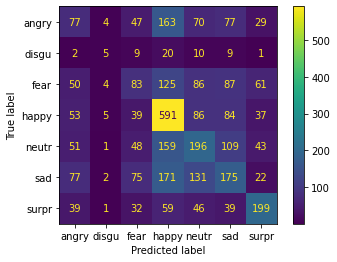

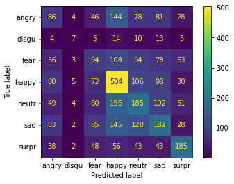

```
PCA Scores
Accuracy of the model trained with PCA is 36.95%
LDA Scores
Accuracy of the model trained with LDA is 34.63%
```

```python
# Visualize the evaluation of test set
model_multi_evaluation2(lr_pca, lr_lda,test_pca_x,test_lda_x,test_y,label_order)
```

[2 Marks] d. Classify the faces using a support vector machine and report your accuracy.